# mediaDash Twitter

Il y a plusieurs groupes sur les réseaux sociaux (Twitter, Facebook, etc…) où des investisseurs individuels échangent leurs avis et parviennent à créer des flux acheteurs ou vendeurs sur des titres. Cette force de frappe va s’organiser progressivement et pourrait même pallier le manque d’informations sur plusieurs sociétés. De plus, l’impact des réseaux sociaux sur les décisions d’investissement est plus important lorsque le marché n’est pas efficient.

Le rapport *mediaDash Twitter* permet de visualiser rapidement une entreprise en termes de :

- Flux de tweets : des forts volumes sont souvent la conséquence d’un événement marquant, impactant potentiellement les prix de l’action
- Contenu des tweets : rapidement, on voit quels sont les sujets les plus abordés
- Sphère twitter autour de cette action : qu’est ce qui motive les tweeters, font-ils de l’investissement ?

## Vue temporelle du flux de tweets

Volume de tweets par minute (somme).

Des pics se produisent à 2022-07-05 11:14:00, 2022-07-05 11:15:00 et ils sont surtout dus à l’activité des users archialemax, lowpoly_tweeter :

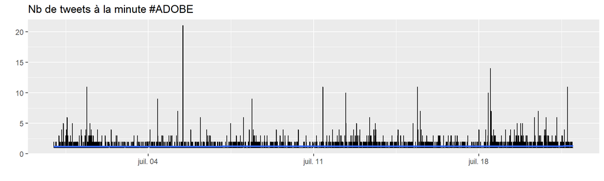

## Sémantique

L’analyse sémantique apporte des informations sur le sentiment et les émotions associées aux tweets.

Le wordcloud permet de visualiser les mots récurrents dans les tweets.

Les tweets les plus fréquents sont (top5 des tweets les plus retweetés) :

| x |
| --- |
| !/ #AdobeFrescoFresco#PR #Adobe #AdobeFresco |
| !/ #AdobeFrescoFresco#PR #Adobe #AdobeFresco |
| !/ #AdobeFrescoFresco#PR #Adobe #AdobeFresco |
| !/ #AdobeFrescoFresco#PR #Adobe #AdobeFresco |
| 2!!#AdobeFresco#adobe #AdobeFresco |

### Mots les plus utilisés

Le top 10 des mots les plus utilisés :

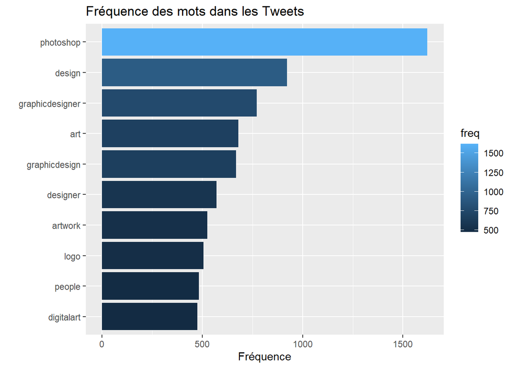

Qui conduit au wordcloud suivant :

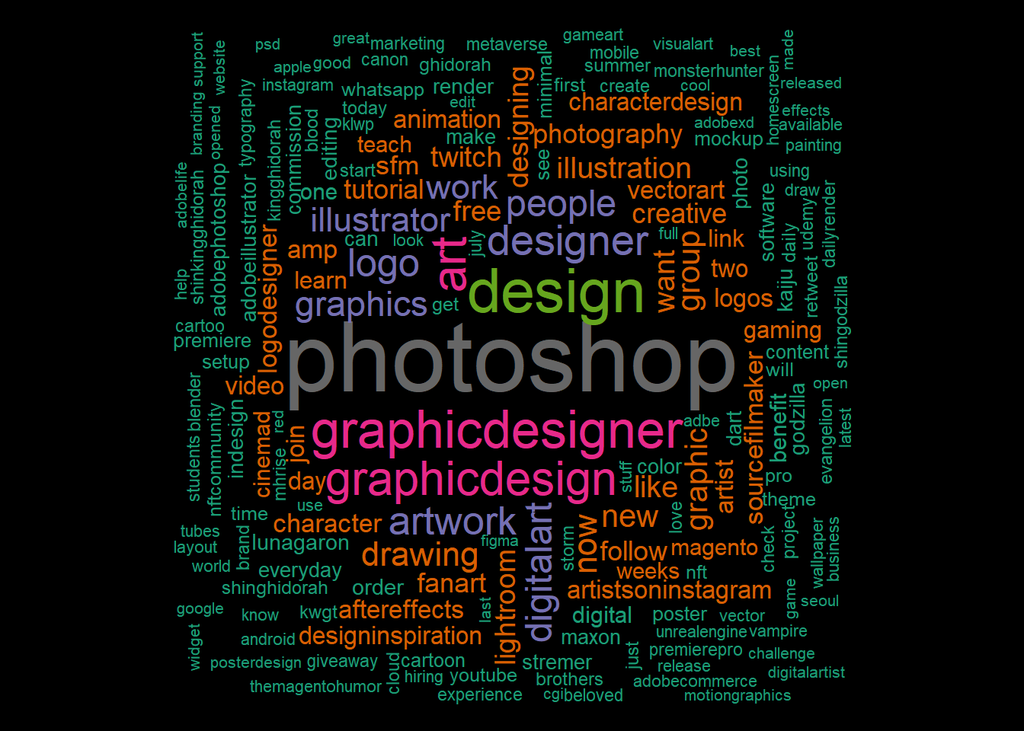

### Sentiment

Nous cherchons ici à savoir si, au vu des tweets, le ressenti concernant l’equity est positif ou négatif.

```
## # A tibble: 1 x 2
##   negative positive
##      <dbl>    <dbl>
## 1     1267     4748
```

Le sentiment prédominant dans les tweets est *positive*

### Emotions

Les émotions qui ressortent le plus de ces tweets sont les suivantes :

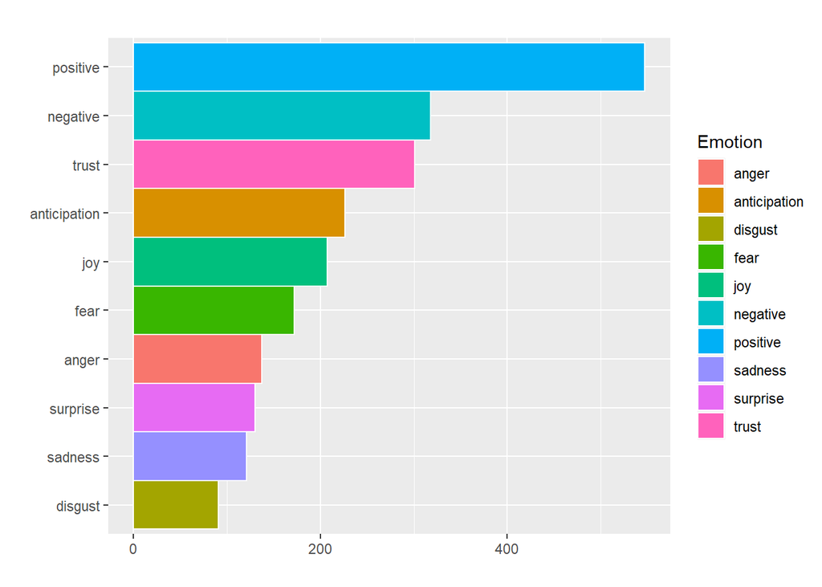

## Vue des utilisateurs

### Top tweeters

La sphère twitter attire des utilisateurs de nature différentes, leurs publications peuvent être motivées par :

- attirer l’attention sur l’entreprise : c’est le cas des services internes de marketing (bots ou humains)
- attirer l’attention sur des entreprises ou des secteurs connexes (exemple lithium-Tesla)
- le journalisme, rendre compte d’un événement particulier
- l’investissement financier

Ce sont ces derniers que l’on va chercher à analyser (sentiment attaché à leurs tweets, émotions, corrélation avec les prix de l’action….)

Des algorithmes de Théorie des Graphe permettent parfois de détecter des communautés, c’est à dire des ensembles de tweeters qui se retweetent.

En général, les centres de chaque communauté sont des tweeters ayant un fort nombre de tweet ; visualisons leur importance relative :

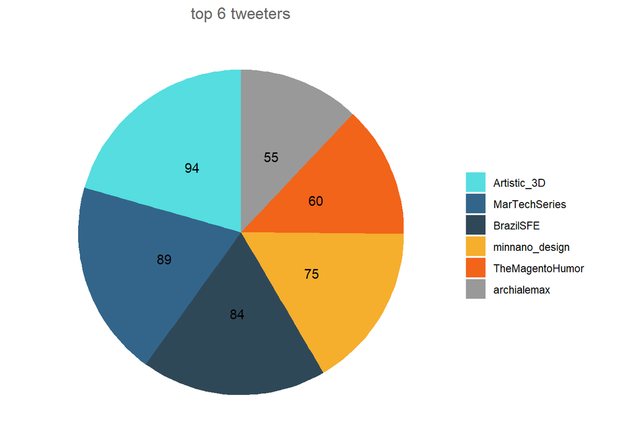

### SNA

La SNA (Social Network Analysis) est un algorithme de Théorie des Graphe utilisé pour modéliser les relations par paires entre tweeters. Un graphe est composé de sommets (utilisateurs) qui sont reliés par des arêtes (liens entre utilisateurs). Cette théorie permet de déceler :

- Des modèles de réseau : décrire comment modéliser la relation entre les utilisateurs
- Des acteurs clés : pour identifier les utilisateurs les plus influents du réseau en fonction d’un contexte différent
- La force du lien : pour mesurer la force de la relation d’un utilisateur
- La cohésion du réseau : pour mesurer la cohésion des entités dans les réseaux vis-à-vis du comportement du réseau.

(pour plus d’information, se référer à https://algotech.netlify.app/blog/social-network-analysis-in-r/)

Nous allons mesurer la centralité de chaque nœud en utilisant:

- Le Degré : Pour trouver des personnes très connectées, des personnes populaires, des personnes susceptibles de détenir la plupart des informations ou des personnes pouvant se connecter rapidement à un réseau plus large.
- Les Intermédiaires : Pour trouver les individus qui influencent le flux autour d’un système.
- les Proximités : Pour trouver les individus les mieux placés pour influencer le plus rapidement l’ensemble du réseau. Eigen : mesure l’influence d’un nœud en fonction du nombre de liens qu’il a avec d’autres nœuds du réseau, puis va plus loin en tenant également compte de la qualité de la connexion d’un nœud, du nombre de liens que possèdent ses connexions, etc. le réseau.

Utilisateurs qui peuvent être considérés comme “importants” :

L’utilisateur le plus mentionné l’a été sur la base des tweets suivants:

```
## [1] "\"Blood Brothers of The Storm\"\n~\n{#Ghidorah #KingGhidorah #ShinGhidorah #ShinKingGhidorah #Godzilla #ShinGodzilla #evangelion #Kaiju #Fanart #Artwork #SFM #SourceFilmaker #Photoshop #Adobe} https://t.co/6KKOFoZmee"
## [2] "Lunagaron my beloved\n~\n{#MonsterHunterRiseSunbreak #MHRise #MonsterHunter #Lunagaron #Fanart #Artwork #SFM #SourceFilmaker #Adobe #photoshop} https://t.co/txadt2ZupG"
## [3] "\"Born In Red Mist\"\n~\n{#Godzilla #GodzillaUltima #GodzillaSingularPoint #Gojira #Kaiju #SFM #SourceFilmaker #Adobe #Photoshop #Artwork #Fanart #Art} https://t.co/Qj4A6kuT8K"
```

```
##  [1] "Papa__Drago"     "JamesGi80104963" "Adobe,"          "UiuxVroo"
##  [5] "molinaripixel"   "YousefGamerYG"   "_Bamdalas"       "AndHA_design"
##  [9] "DTP_Transit"     "asahi_nel"       "Canada9ja"       "Justbrown__x"
## [13] "commonstyle"     "sajad_machu"     "AdobeExpCloud"   "AdobeES,"
## [17] "AdobeLat,"
```

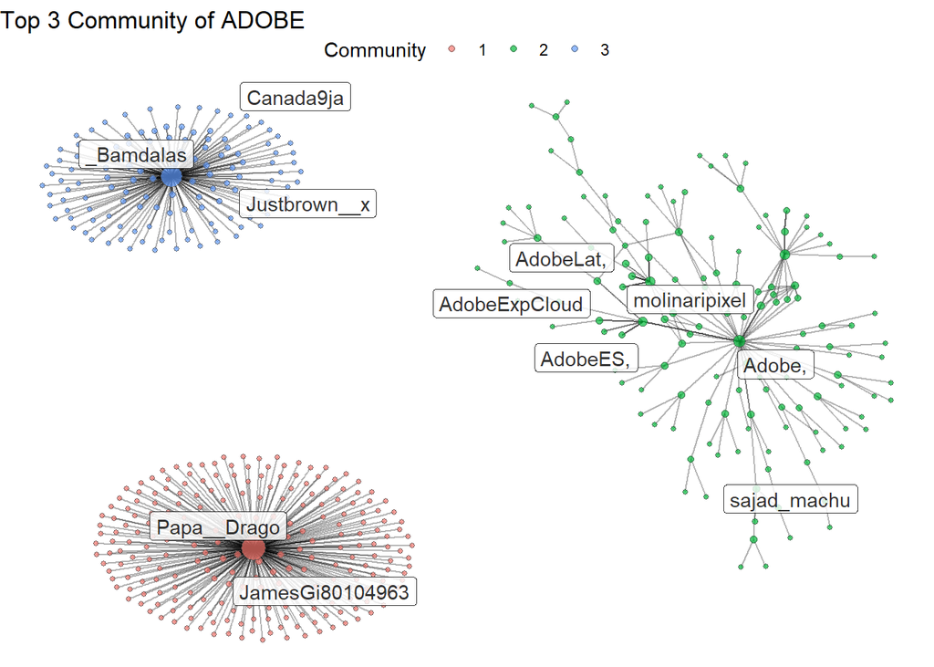

## Corrélations

Communauté 2, avec un offset de 1 jour

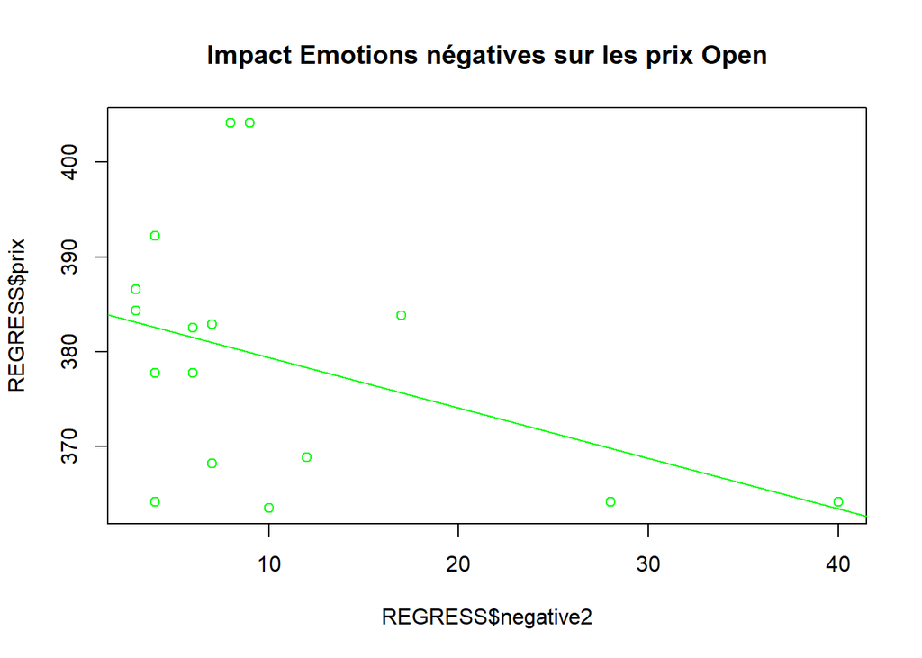

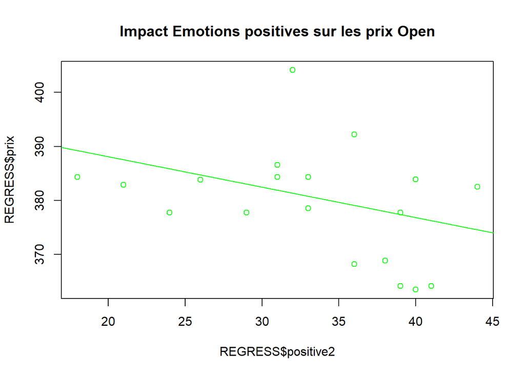

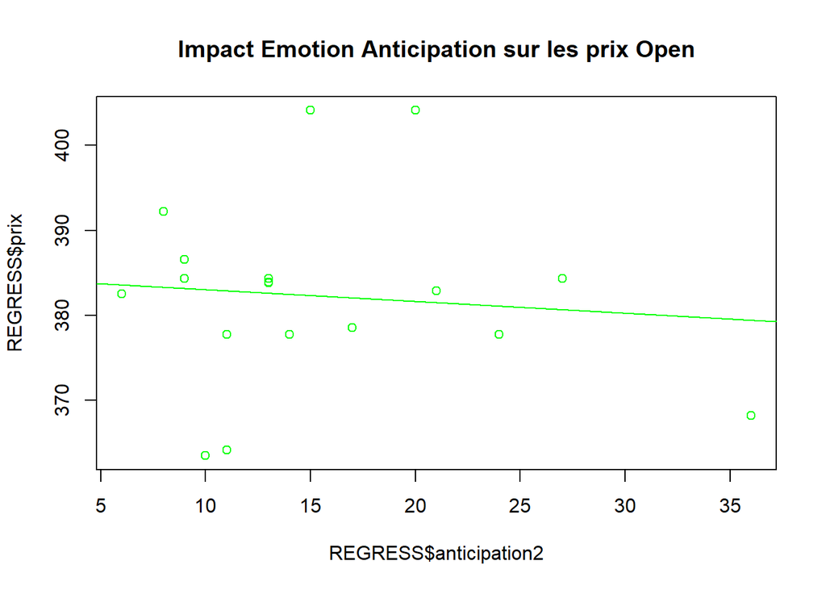

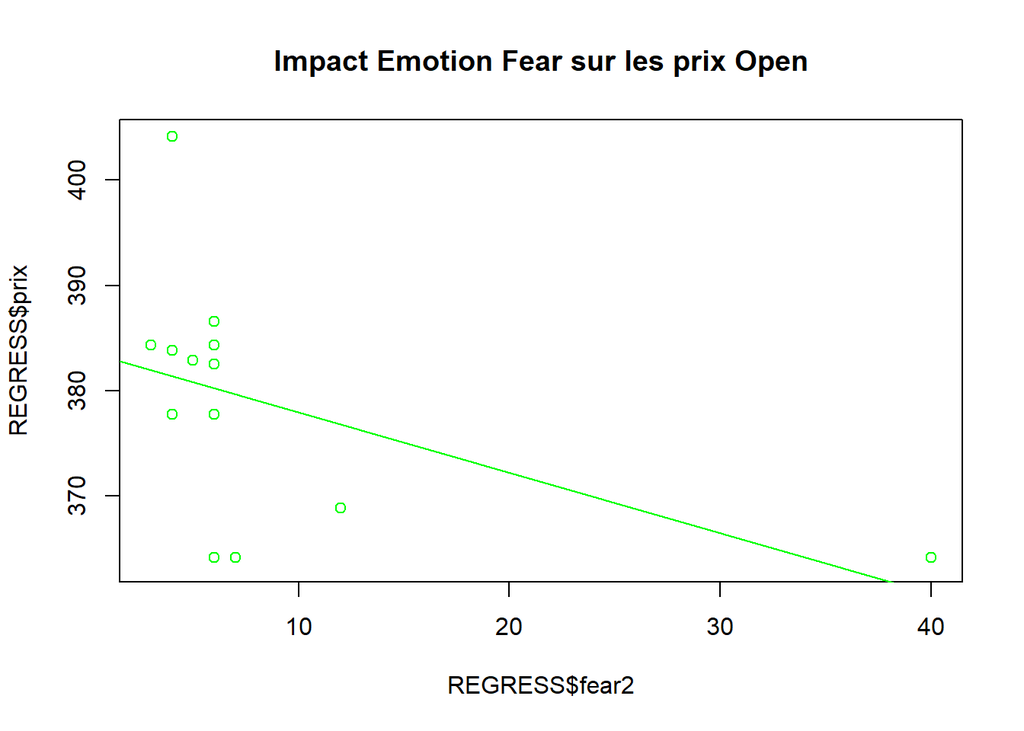

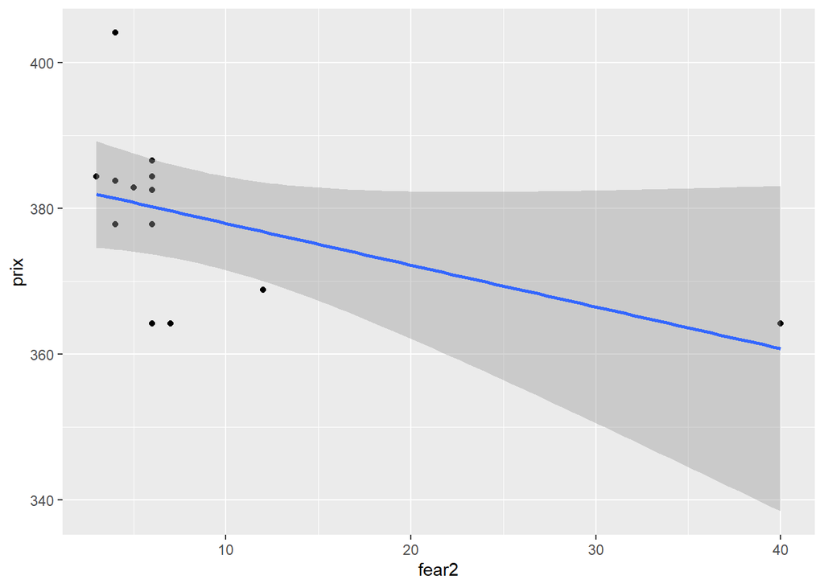